# Build eight Gudenå nature-restoration scenarios

# 1 Purpose and scope

This is **predictor preparation only**. It does not download occurrences, fit plant models, or calculate biodiversity. Run the separate targets_plant_biodiversity.R script after these inputs pass their audits.

This document retains the design of your original workflow:

- fit species models with national Danish land use and current CHELSA;
- project current conditions and eight restoration scenarios only in Gudenå;
- replace every current Agriculture and ProductionForest cell with one of the eight nature types in each scenario;
- leave existing nature, Urban, Other and missing cells unchanged.

ProductionForest retains the **proxy definition from document 01**, not a newly verified forest-management inventory. These are extreme endpoint scenarios, not predictions of restoration feasibility, timescale or colonisation.

The 10 m national land use is sampled onto the existing CHELSA grid with nearest neighbour. CHELSA is interpolated to 10 m **only in Gudenå**. Interpolation does not create 10 m climate information. Training with coarse land-use cells and projecting to fine habitat patches is a scale-transfer assumption; inspect the pilot before interpreting local effects as validated 10 m predictions. All nine local projections use the same current climate.

# 2 Before running

Your listed Predictors folder contains land use, not CHELSA. Set current_climate_file above to the existing **five-band current CHELSA TIFF**. An absolute path to the existing SpeciesPoolRExample project is acceptable. Alternatively, supply an existing current_predictor_paths.rds that references exactly one climate stack. No climate data are downloaded by this document.

The boundary shapefile must have matching .shp, .shx, .dbf and .prj basenames. The workflow stops on a missing CRS; it does not guess one.

Raster processing uses one thread and an 8 GB terra memory budget by default. This encourages file-backed operations; it is not a hard process-memory limit.

# 3 Restarting and recovering

Completed rasters and tabular intermediates are stored under Intermediates/gudenaa_scenarios. Re-knit this document after an interruption: completed matching stages print [reuse]. Only incomplete or invalidated stages are rebuilt. No live SpatRaster pointers are saved in RDS checkpoints.

Each stage has a content key for its inputs, recipe, parameters and terra version. Metadata fingerprinting checks file paths, sizes and modification times, and hashes small files. Choose input_fingerprint: “md5” for full content hashing of large TIFFs too; this costs an extra read of those files. Sidecars are included. Do not modify source files while this document is running.

The eight scenario rasters and their audits are checkpointed separately. A later plotting/export failure will not require repeating their calculation. Keep the intermediates and this project together; checkpoints contain absolute paths and are not automatically relocatable. Never knit two copies into the same output/intermediate folders concurrently.

A matching published output is reused even with overwrite: false. An unrelated or changed existing output is protected. To deliberately replace it, set overwrite: true; completed intermediates can still be reused. Old checkpoint versions are retained, not automatically deleted.

```r
knitr::opts_chunk$set(
  collapse = TRUE, comment = "#>", error = FALSE,
  message = TRUE, warning = TRUE, cache = FALSE
)
required_packages <- c("terra", "dplyr", "readr", "tibble", "knitr", "digest")
missing_packages <- required_packages[
  !vapply(required_packages, requireNamespace, logical(1), quietly = TRUE)
]
if (length(missing_packages)) {
  stop("Install these packages first: ",
       paste(missing_packages, collapse = ", "), call. = FALSE)
}
Sys.setenv(OMP_NUM_THREADS = "1", OPENBLAS_NUM_THREADS = "1",
           MKL_NUM_THREADS = "1", VECLIB_MAXIMUM_THREADS = "1",
           GDAL_NUM_THREADS = "1")
library(terra)
library(dplyr)
if (length(params$terra_memmax_gb) != 1L ||
    !is.finite(params$terra_memmax_gb) || params$terra_memmax_gb <= 0) {
  stop("terra_memmax_gb must be one positive finite number.")
}
terra_settings <- list(progress = 1L, memmax = params$terra_memmax_gb,
                       memmin = 0, memfrac = 0.05)
if ("threads" %in% names(terra::terraOptions(print = FALSE))) {
  terra_settings$threads <- 1L
}
do.call(terra::terraOptions, terra_settings)
if (!params$input_fingerprint %in% c("metadata", "md5")) {
  stop("input_fingerprint must be metadata or md5.")
}
if (length(params$expected_climate_layers) != 1L ||
    !is.finite(params$expected_climate_layers) ||
    params$expected_climate_layers < 1 ||
    params$expected_climate_layers != floor(params$expected_climate_layers)) {
  stop("expected_climate_layers must be a positive integer.")
}
dir.create(params$intermediate_dir, recursive = TRUE, showWarnings = FALSE)
checkpoint_records <- new.env(parent = emptyenv())
```

# 4 Helpers

```r
assert_files_exist <- function(paths) {
  if (!is.character(paths) || !length(paths) || anyNA(paths) || any(!nzchar(paths))) {
    stop("Input paths must be non-empty character strings.", call. = FALSE)
  }
  missing <- paths[!file.exists(paths)]
  if (length(missing)) {
    stop("Missing input files:\n- ", paste(missing, collapse = "\n- "), call. = FALSE)
  }
  invisible(paths)
}
snake_case <- function(x) {
  x <- gsub("([a-z0-9])([A-Z])", "\\1_\\2", x)
  tolower(gsub("^_+|_+$", "", gsub("[^A-Za-z0-9]+", "_", x)))
}
count_true <- function(x) {
  as.numeric(terra::global(terra::ifel(!is.na(x) & x, 1, 0),
                           fun = "sum", na.rm = TRUE)[1, 1])
}
sum_where <- function(values, condition) {
  as.numeric(terra::global(terra::ifel(!is.na(condition) & condition, values, NA),
                           fun = "sum", na.rm = TRUE)[1, 1])
}
complete_domain <- function(x) {
  valid <- terra::app(is.finite(x), fun = "sum")
  out <- terra::ifel(valid == terra::nlyr(x), 1, NA)
  names(out) <- "prediction_domain"
  out
}
scenario_values <- function(current, target_id, convertible_ids) {
  current <- as.numeric(current)
  terra::ifel(current %in% convertible_ids, target_id, current)
}
validate_ids <- function(x, allowed) {
  tab <- terra::freq(as.numeric(x))
  if (is.null(tab) || !nrow(tab) ||
      any(!tab$value %in% allowed) || any(!is.finite(tab$value))) {
    stop("Land use is empty or has IDs outside the legend.", call. = FALSE)
  }
  tab
}
assert_crs <- function(x, label) {
  if (!nzchar(terra::crs(x))) {
    stop(label, " has no readable CRS. Check its metadata / matching .prj file.",
         call. = FALSE)
  }
  invisible(x)
}
read_boundary <- function(path, target_crs) {
  x <- terra::vect(path)
  assert_crs(x, "Gudenå boundary")
  terra::project(terra::aggregate(terra::makeValid(x)), target_crs)
}
resolve_current_climate <- function(explicit_path, predictor_manifest) {
  if (is.character(explicit_path) && length(explicit_path) == 1L &&
      !is.na(explicit_path) && nzchar(explicit_path)) {
    assert_files_exist(explicit_path)
    return(explicit_path)
  }
  if (!file.exists(predictor_manifest)) {
    stop(
      "No current CHELSA stack was supplied. Set current_climate_file to your ",
      "existing five-band TIFF. The default fallback manifest also does not exist: ",
      predictor_manifest, ". This document does not download climate data.",
      call. = FALSE
    )
  }
  paths <- unique(unlist(readRDS(predictor_manifest), use.names = FALSE))
  assert_files_exist(paths)
  candidates <- paths[vapply(paths, function(path) {
    x <- terra::rast(path)
    terra::nlyr(x) == params$expected_climate_layers &&
      !any(terra::is.factor(x)) &&
      !any(tolower(names(x)) == "landuse")
  }, logical(1))]
  if (length(candidates) != 1L) {
    stop("Cannot identify exactly one current climate stack. ",
         "Set current_climate_file explicitly.", call. = FALSE)
  }
  candidates[[1]]
}
# Tiny final tables/manifests are regenerated cheaply, but not silently replaced
# when they belong to a different run.
write_small_output <- function(object, filename, kind = c("rds", "csv")) {
  kind <- match.arg(kind)
  dir.create(dirname(filename), recursive = TRUE, showWarnings = FALSE)
  tmp <- tempfile("publish_table_", tmpdir = dirname(filename))
  on.exit(unlink(tmp), add = TRUE)
  if (kind == "rds") saveRDS(object, tmp) else {
    readr::write_csv(object, tmp, na = "")
  }
  if (file.exists(filename)) {
    same <- identical(unname(tools::md5sum(tmp)), unname(tools::md5sum(filename)))
    if (same) return(filename)
    if (!isTRUE(params$overwrite)) {
      stop("Existing table/manifest differs: ", filename,
           ". Set overwrite: true only if replacement is intended.", call. = FALSE)
    }
  }
  if (!file.copy(tmp, filename, overwrite = TRUE)) {
    stop("Cannot publish ", filename, call. = FALSE)
  }
  filename
}
```

```r
file_stamp <- function(paths) {
  if (!length(paths) || any(!file.exists(paths))) return(NULL)
  info <- file.info(paths)
  if (any(is.na(info$size)) || any(info$isdir)) return(NULL)
  data.frame(
    path = normalizePath(paths, winslash = "/", mustWork = TRUE),
    bytes = as.numeric(info$size),
    modified = as.numeric(info$mtime),
    stringsAsFactors = FALSE,
    row.names = NULL
  )
}

input_signature <- function(path) {
  assert_files_exist(path)
  if (tolower(tools::file_ext(path)) == "vrt") {
    stop("Materialize VRT inputs to GeoTIFF before checkpointing.", call. = FALSE)
  }
  stem <- tools::file_path_sans_ext(path)
  sidecars <- c(
    paste0(path, c(".aux.xml", ".vat.dbf", ".ovr", ".xml")),
    paste0(stem, c(".prj", ".PRJ", ".tfw", ".TFW", ".wld", ".ige"))
  )
  if (tolower(tools::file_ext(path)) == "shp") {
    sidecars <- c(sidecars, paste0(stem, c(
      ".dbf", ".shx", ".cpg", ".qix", ".sbn", ".sbx",
      ".DBF", ".SHX", ".CPG"
    )))
  }
  paths <- sort(unique(c(path, sidecars[file.exists(sidecars)])))
  stamp <- file_stamp(paths)
  if (is.null(stamp)) stop("Cannot fingerprint input: ", path, call. = FALSE)
  hash_files <- params$input_fingerprint == "md5" | stamp$bytes <= 10 * 1024^2
  stamp$md5 <- NA_character_
  if (any(hash_files)) {
    stamp$md5[hash_files] <- unname(tools::md5sum(stamp$path[hash_files]))
    if (anyNA(stamp$md5[hash_files])) {
      stop("Cannot hash an input file for: ", path, call. = FALSE)
    }
  }
  stamp
}

checkpoint_ref <- function(name) {
  record <- get(name, envir = checkpoint_records, inherits = FALSE)
  list(key = record$key, files = record$files)
}

checkpoint_stage <- function(
    name, inputs, build, kind = c("raster", "rds"),
    helpers = list(), datatype = "INT1U",
    category_table = NULL, layer_name = NULL) {
  kind <- match.arg(kind)
  stopifnot(length(name) == 1L, grepl("^[A-Za-z0-9_]+$", name))
  # Hash code text, not source-reference attributes or closure environments:
  # temporary knit filenames and changed report line numbers are not inputs.
  function_code <- function(f) list(
    formals = paste(deparse(formals(f), width.cutoff = 500L,
                           control = c("keepInteger", "keepNA")), collapse = "\n"),
    body = paste(deparse(body(f), width.cutoff = 500L,
                        control = c("keepInteger", "keepNA")), collapse = "\n")
  )
  key <- digest::digest(list(
    schema = 2L,
    revision = params$checkpoint_revision,
    terra = as.character(utils::packageVersion("terra")),
    kind = kind, datatype = datatype,
    categories = category_table, layer_name = layer_name,
    inputs = inputs,
    recipe = function_code(build),
    helpers = lapply(helpers, function_code)
  ), algo = "xxhash64")
  stage_dir <- file.path(params$intermediate_dir, name, key)
  marker_path <- file.path(stage_dir, "complete.rds")
  record <- if (file.exists(marker_path)) {
    tryCatch(readRDS(marker_path), error = function(e) NULL)
  } else NULL

  restore <- function(record) {
    if (identical(record$kind, "rds")) return(readRDS(record$path))
    x <- terra::rast(record$path)
    if (terra::nlyr(x) != length(record$layer_names)) {
      stop("Invalid checkpoint layer count.")
    }
    if (is.data.frame(record$category_table) &&
        ncol(record$category_table) >= 2L) {
      levels(x) <- record$category_table
    }
    names(x) <- record$layer_names
    x
  }

  if (is.list(record) && identical(record$key, key) &&
      is.data.frame(record$files) && nrow(record$files) > 0L &&
      identical(file_stamp(record$files$path), record$files)) {
    cached <- tryCatch(restore(record), error = function(e) NULL)
    if (!is.null(cached)) {
      assign(name, record, envir = checkpoint_records)
      message("[reuse] ", name)
      return(cached)
    }
  }

  message("[build] ", name)
  dir.create(stage_dir, recursive = TRUE, showWarnings = FALSE)
  artifact_path <- tempfile(
    pattern = paste0(name, "_"), tmpdir = stage_dir,
    fileext = if (kind == "raster") ".tif" else ".rds"
  )
  value <- build()
  record <- list(key = key, kind = kind)
  if (kind == "raster") {
    stopifnot(inherits(value, "SpatRaster"), terra::nlyr(value) >= 1L)
    if (!is.null(category_table) && terra::nlyr(value) != 1L) {
      stop("Category tables are only supported for a single categorical layer.")
    }
    if (!is.null(category_table)) levels(value) <- category_table
    if (!is.null(layer_name)) names(value) <- layer_name
    record$layer_names <- names(value)
    category_tables <- terra::levels(value)
    record$category_table <- if (length(category_tables)) {
      category_tables[[1]]
    } else NULL
    wopt <- list(
      datatype = datatype,
      gdal = c("COMPRESS=DEFLATE", "TILED=YES", "BIGTIFF=IF_SAFER")
    )
    if (datatype == "INT1U") wopt$NAflag <- 255
    terra::writeRaster(value, filename = artifact_path, overwrite = FALSE,
                       wopt = wopt)
  } else {
    saveRDS(value, artifact_path)
  }
  record$path <- normalizePath(artifact_path, winslash = "/", mustWork = TRUE)
  # These are the sidecars generated/used by our GeoTIFF checkpoints.
  sidecars <- paste0(record$path, c(".aux.xml", ".vat.dbf", ".ovr"))
  record$files <- file_stamp(c(record$path, sidecars[file.exists(sidecars)]))
  if (is.null(record$files)) stop("Checkpoint write failed for ", name)
  result <- restore(record)
  record$completed_at <- format(Sys.time(), tz = "UTC", usetz = TRUE)
  # Written last: an interrupted/truncated marker is never a cache hit.
  saveRDS(record, marker_path)
  assign(name, record, envir = checkpoint_records)
  message("[saved] ", name)
  result
}

publish_checkpoint <- function(name, filename, overwrite = FALSE) {
  record <- get(name, envir = checkpoint_records, inherits = FALSE)
  stopifnot(identical(record$kind, "raster"))
  dir.create(dirname(filename), recursive = TRUE, showWarnings = FALSE)
  marker <- paste0(filename, ".checkpoint.rds")
  previous <- if (file.exists(marker)) {
    tryCatch(readRDS(marker), error = function(e) NULL)
  } else NULL
  reference <- checkpoint_ref(name)
  same_source <- is.list(previous) && identical(previous$source, reference)
  if (same_source && identical(previous$state, "complete") &&
      is.data.frame(previous$files) &&
      identical(file_stamp(previous$files$path), previous$files)) {
    message("[reuse output] ", filename)
    return(filename)
  }
  # Copy the compressed TIFF plus its category sidecars, rather than
  # decompressing and recompressing the national raster a second time.
  suffix <- substring(record$files$path, nchar(record$path) + 1L)
  destinations <- paste0(filename, suffix)
  known_sidecars <- paste0(filename, c(".aux.xml", ".vat.dbf", ".ovr"))
  existing <- unique(c(destinations, known_sidecars))
  continuing_own_copy <- same_source && identical(previous$state, "writing")
  if (any(file.exists(existing)) && !isTRUE(overwrite) && !continuing_own_copy) {
    stop(
      "Existing output has no matching completed checkpoint: ", filename,
      ". Choose a new output_dir, or set overwrite: true if replacement ",
      "is intended. All completed intermediates remain available.",
      call. = FALSE
    )
  }
  saveRDS(list(source = reference, state = "writing"), marker)
  # Only obsolete sidecars for this explicitly permitted output are removed.
  obsolete <- setdiff(known_sidecars, destinations)
  obsolete <- obsolete[file.exists(obsolete)]
  if (length(obsolete) && any(unlink(obsolete) != 0L)) {
    stop("Could not remove obsolete sidecars for ", filename, call. = FALSE)
  }
  copied <- file.copy(record$files$path, destinations, overwrite = TRUE)
  if (!all(copied)) stop("Could not finish copying output: ", filename)
  output_files <- file_stamp(destinations)
  if (is.null(output_files) ||
      !identical(output_files$bytes, record$files$bytes)) {
    stop("Output copy has an unexpected size: ", filename, call. = FALSE)
  }
  terra::rast(filename) # Confirm that the published TIFF can be opened.
  saveRDS(list(source = reference, state = "complete", files = output_files), marker)
  message("[published] ", filename)
  filename
}
```

[output not shown]

# 5 Read and validate sources

```r
assert_files_exist(c(params$national_current_landuse_file,
                     params$current_landuse_file, params$landuse_legend_file,
                     params$gudenaa_file))
current_climate_source <- resolve_current_climate(
  params$current_climate_file, params$current_predictor_manifest_file
)
landuse_legend <- as.data.frame(readr::read_csv(
  params$landuse_legend_file, show_col_types = FALSE, progress = FALSE
))
required_legend_columns <- c("id", "class", "role")
if (!all(required_legend_columns %in% names(landuse_legend))) {
  stop("The legend must contain id, class and role.")
}
expected_classes <- c(
  "ForestDryPoor", "ForestWetPoor", "ForestDryRich", "ForestWetRich",
  "OpenDryPoor", "OpenWetPoor", "OpenDryRich", "OpenWetRich",
  "Agriculture", "Urban", "ProductionForest", "Other"
)
if (nrow(landuse_legend) != 12L || anyNA(landuse_legend$id) ||
    anyDuplicated(landuse_legend$id) || anyDuplicated(landuse_legend$class) ||
    !identical(as.integer(landuse_legend$id[match(expected_classes, landuse_legend$class)]),
               1:12)) {
  stop("The legend must preserve the 12 class IDs established in document 01.")
}
if (!setequal(landuse_legend$class[landuse_legend$role %in% "nature"],
              expected_classes[1:8])) {
  stop("The nature role must identify exactly the eight nature types.")
}
class_table <- data.frame(id = as.integer(landuse_legend$id),
                          class = as.character(landuse_legend$class))
convertible_ids <- c(9L, 11L)
national_current_landuse <- terra::rast(params$national_current_landuse_file)
current_landuse <- terra::rast(params$current_landuse_file)
climate_source <- terra::rast(current_climate_source)
for (x in list(national_current_landuse, current_landuse, climate_source)) {
  assert_crs(x, "An input raster")
}
stopifnot(terra::nlyr(national_current_landuse) == 1L,
          terra::nlyr(current_landuse) == 1L)
if (terra::nlyr(climate_source) != params$expected_climate_layers ||
    any(terra::is.factor(climate_source)) || anyNA(names(climate_source)) ||
    any(!nzchar(names(climate_source))) || anyDuplicated(names(climate_source)) ||
    any(tolower(names(climate_source)) == "landuse")) {
  stop("CHELSA must contain the expected number of uniquely named continuous bands.")
}
climate_names <- names(climate_source)
names(national_current_landuse) <- "Landuse"
names(current_landuse) <- "Landuse"
gudenaa <- read_boundary(params$gudenaa_file, terra::crs(current_landuse))
source_signatures <- list(
  national_landuse = input_signature(params$national_current_landuse_file),
  local_landuse = input_signature(params$current_landuse_file),
  climate = input_signature(current_climate_source),
  boundary = input_signature(params$gudenaa_file),
  legend = input_signature(params$landuse_legend_file)
)
dir.create(params$output_dir, recursive = TRUE, showWarnings = FALSE)
```

# 6 National training predictors

The original CHELSA stack is cropped to the national land-use extent first. This prevents an accidentally larger climate input from causing global training projections. Both training files are published locally with matching geometry.

```r
training_climate_unmasked <- checkpoint_stage(
  "01_climate_Denmark_crop",
  inputs = list(climate = source_signatures$climate,
                landuse = source_signatures$national_landuse, bands = climate_names),
  datatype = "FLT4S", layer_name = climate_names,
  build = function() {
    footprint <- terra::as.polygons(terra::ext(national_current_landuse),
                                    crs = terra::crs(national_current_landuse))
    footprint <- terra::project(footprint, terra::crs(climate_source))
    terra::crop(climate_source, footprint, snap = "out")
  }
)
```

```
#> [build] 01_climate_Denmark_crop
#> |---------|---------|---------|---------|=========================================                                          |---------|---------|---------|---------|=========================================
#> [saved] 01_climate_Denmark_crop
```

```r
training_landuse_unmasked <- checkpoint_stage(
  "02_landuse_Denmark_CHELSA_grid",
  inputs = list(source = source_signatures$national_landuse,
                climate = checkpoint_ref("01_climate_Denmark_crop"),
                categories = class_table),
  category_table = class_table, layer_name = "Landuse",
  build = function() {
    terra::project(as.numeric(national_current_landuse),
                   training_climate_unmasked[[1]], method = "near")
  }
)
```

```
#> [build] 02_landuse_Denmark_CHELSA_grid
#> |---------|---------|---------|---------|=========================================                                          |---------|---------|---------|---------|=========================================
#> [saved] 02_landuse_Denmark_CHELSA_grid
```

```r
training_domain <- checkpoint_stage(
  "03_training_domain",
  inputs = list(landuse = checkpoint_ref("02_landuse_Denmark_CHELSA_grid"),
                climate = checkpoint_ref("01_climate_Denmark_crop")),
  helpers = list(complete_domain), layer_name = "prediction_domain",
  build = function() {
    complete_domain(c(as.numeric(training_landuse_unmasked), training_climate_unmasked))
  }
)
```

```
#> [build] 03_training_domain
#> |---------|---------|---------|---------|=========================================                                          |---------|---------|---------|---------|=========================================                                          |---------|---------|---------|---------|========…
#> [saved] 03_training_domain
```

```r
training_landuse <- checkpoint_stage(
  "04_training_landuse",
  inputs = list(landuse = checkpoint_ref("02_landuse_Denmark_CHELSA_grid"),
                domain = checkpoint_ref("03_training_domain")),
  category_table = class_table, layer_name = "Landuse",
  build = function() terra::mask(as.numeric(training_landuse_unmasked), training_domain)
)
```

```
#> [build] 04_training_landuse
#> |---------|---------|---------|---------|=========================================                                          |---------|---------|---------|---------|=========================================
#> [saved] 04_training_landuse
```

```r
training_climate <- checkpoint_stage(
  "05_training_climate",
  inputs = list(climate = checkpoint_ref("01_climate_Denmark_crop"),
                domain = checkpoint_ref("03_training_domain")),
  datatype = "FLT4S", layer_name = climate_names,
  build = function() terra::mask(training_climate_unmasked, training_domain)
)
```

```
#> [build] 05_training_climate
#> |---------|---------|---------|---------|=========================================                                          |---------|---------|---------|---------|=========================================
#> [saved] 05_training_climate
```

```r
training_audit <- checkpoint_stage(
  "06_training_audit",
  inputs = list(landuse = checkpoint_ref("04_training_landuse"),
                climate = checkpoint_ref("05_training_climate"),
                categories = class_table),
  kind = "rds", helpers = list(validate_ids, count_true),
  build = function() {
    stopifnot(terra::compareGeom(training_landuse, training_climate))
    tab <- validate_ids(training_landuse, class_table$id)
    if (!all(1:8 %in% tab$value)) {
      stop("One or more restoration categories disappeared on the training grid. ",
           "Inspect the land-use class audit before fitting.")
    }
    data.frame(id = tab$value,
               class = class_table$class[match(tab$value, class_table$id)],
               cells = tab$count)
  }
)
```

```
#> [build] 06_training_audit
#> [saved] 06_training_audit
```

```r
knitr::kable(training_audit)
```

| id | class | cells |
| --- | --- | --- |
| 1 | ForestDryPoor | 15041 |
| 2 | ForestWetPoor | 2009 |
| 3 | ForestDryRich | 1944 |
| 4 | ForestWetRich | 1836 |
| 5 | OpenDryPoor | 93810 |
| 6 | OpenWetPoor | 8597 |
| 7 | OpenDryRich | 15141 |
| 8 | OpenWetRich | 166919 |
| 9 | Agriculture | 1970594 |
| 10 | Urban | 438594 |
| 11 | ProductionForest | 409479 |
| 12 | Other | 183688 |

# 7 Local current predictors and common prediction domain

The published local baseline is a category-preserving, boundary-masked copy. Its geometry and class IDs are shared by all eight scenarios. The separate prediction-domain raster excludes cells missing any climate band; it is the same for every biodiversity comparison.

```r
current_local <- checkpoint_stage(
  "07_local_landuse",
  inputs = list(landuse = source_signatures$local_landuse,
                boundary = source_signatures$boundary, categories = class_table),
  category_table = class_table, layer_name = "Landuse",
  build = function() terra::mask(as.numeric(current_landuse), gudenaa)
)
```

```
#> [build] 07_local_landuse
#> |---------|---------|---------|---------|=========================================                                          |---------|---------|---------|---------|=========================================                                          |---------|---------|---------|---------|========…
#> [saved] 07_local_landuse
```

```r
climate_local_projected <- checkpoint_stage(
  "08_climate_local_projected",
  inputs = list(source = source_signatures$climate,
                template = checkpoint_ref("07_local_landuse"), bands = climate_names),
  datatype = "FLT4S", layer_name = climate_names,
  build = function() {
    terra::project(climate_source, current_local, method = "bilinear")
  }
)
```

```
#> [build] 08_climate_local_projected
#> |---------|---------|---------|---------|=========================================                                          |---------|---------|---------|---------|=========================================
#> [saved] 08_climate_local_projected
```

```r
climate_local <- checkpoint_stage(
  "09_climate_local_masked",
  inputs = list(climate = checkpoint_ref("08_climate_local_projected"),
                landuse = checkpoint_ref("07_local_landuse")),
  datatype = "FLT4S", layer_name = climate_names,
  build = function() terra::mask(climate_local_projected, current_local)
)
```

```
#> [build] 09_climate_local_masked
#> |---------|---------|---------|---------|=========================================                                          |---------|---------|---------|---------|=========================================
#> [saved] 09_climate_local_masked
```

```r
local_domain <- checkpoint_stage(
  "10_local_prediction_domain",
  inputs = list(landuse = checkpoint_ref("07_local_landuse"),
                climate = checkpoint_ref("09_climate_local_masked")),
  helpers = list(complete_domain), layer_name = "prediction_domain",
  build = function() complete_domain(c(as.numeric(current_local), climate_local))
)
```

```
#> [build] 10_local_prediction_domain
#> |---------|---------|---------|---------|=========================================                                          |---------|---------|---------|---------|=========================================                                          |---------|---------|---------|---------|========…
#> [saved] 10_local_prediction_domain
```

```r
local_audit <- checkpoint_stage(
  "11_local_audit",
  inputs = list(landuse = checkpoint_ref("07_local_landuse"),
                climate = checkpoint_ref("09_climate_local_masked"),
                domain = checkpoint_ref("10_local_prediction_domain"),
                legend = class_table),
  kind = "rds", helpers = list(validate_ids, count_true),
  build = function() {
    stopifnot(terra::compareGeom(current_local, climate_local))
    validate_ids(current_local, class_table$id)
    n <- count_true(!is.na(local_domain))
    if (!is.finite(n) || n == 0) stop("The local complete predictor domain is empty.")
    data.frame(local_landuse_cells = count_true(!is.na(current_local)),
               complete_predictor_cells = n,
               landuse_cells_missing_climate = count_true(
                 !is.na(current_local) & is.na(local_domain)))
  }
)
```

```
#> [build] 11_local_audit
#> |---------|---------|---------|---------|=========================================                                          |---------|---------|---------|---------|=========================================                                          |---------|---------|---------|---------|========…
#> [saved] 11_local_audit
```

```r
knitr::kable(local_audit)
```

| local_landuse_cells | complete_predictor_cells | landuse_cells_missing_climate |
| --- | --- | --- |
| 66007375 | 65666042 | 341333 |

# 8 Conversion mask and scenario specification

```r
scenario_table <- data.frame(
  scenario = paste0("all_to_", vapply(expected_classes[1:8], snake_case, character(1))),
  target_id = 1:8, target_class = expected_classes[1:8]
)
convertible_mask <- checkpoint_stage(
  "12_convertible_mask",
  inputs = list(landuse = checkpoint_ref("07_local_landuse"), ids = convertible_ids),
  layer_name = "convertible",
  build = function() {
    terra::mask(terra::ifel(as.numeric(current_local) %in% convertible_ids, 1, 0),
                current_local)
  }
)
```

```
#> [build] 12_convertible_mask
#> |---------|---------|---------|---------|=========================================                                          |---------|---------|---------|---------|=========================================                                          |---------|---------|---------|---------|========…
#> [saved] 12_convertible_mask
```

```r
cell_area_km2 <- checkpoint_stage(
  "13_local_cell_area",
  inputs = list(template = checkpoint_ref("07_local_landuse")),
  datatype = "FLT8S", layer_name = "cell_area_km2",
  build = function() terra::mask(terra::cellSize(current_local, unit = "km"), current_local)
)
```

```
#> [build] 13_local_cell_area
#> |---------|---------|---------|---------|=========================================                                          |---------|---------|---------|---------|=========================================                                          |---------|---------|---------|---------|========…
#> [saved] 13_local_cell_area
```

```r
conversion_audit <- checkpoint_stage(
  "14_conversion_audit",
  inputs = list(mask = checkpoint_ref("12_convertible_mask"),
                area = checkpoint_ref("13_local_cell_area")),
  kind = "rds", helpers = list(count_true, sum_where),
  build = function() {
    n <- count_true(convertible_mask == 1)
    if (!is.finite(n) || n == 0) stop("No Agriculture/ProductionForest cells were found.")
    data.frame(convertible_cells = n,
               convertible_area_km2 = sum_where(cell_area_km2, convertible_mask == 1))
  }
)
```

```
#> [build] 14_conversion_audit
#> |---------|---------|---------|---------|=========================================                                          |---------|---------|---------|---------|=========================================                                          |---------|---------|---------|---------|========…
#> [saved] 14_conversion_audit
```

```r
knitr::kable(scenario_table)
```

| scenario | target_id | target_class |
| --- | --- | --- |
| all_to_forest_dry_poor | 1 | ForestDryPoor |
| all_to_forest_wet_poor | 2 | ForestWetPoor |
| all_to_forest_dry_rich | 3 | ForestDryRich |
| all_to_forest_wet_rich | 4 | ForestWetRich |
| all_to_open_dry_poor | 5 | OpenDryPoor |
| all_to_open_wet_poor | 6 | OpenWetPoor |
| all_to_open_dry_rich | 7 | OpenDryRich |
| all_to_open_wet_rich | 8 | OpenWetRich |

```r
knitr::kable(conversion_audit, digits = 3)
```

| convertible_cells | convertible_area_km2 |
| --- | --- |
| 48027059 | 4806.057 |

# 9 Build and audit each scenario independently

A checkpoint is marked complete only after the TIFF can be reopened. The separate audit verifies the missing-cell mask too, so new NA cells cannot silently pass the changed-cell checks.

```r
scenario_results <- vector("list", nrow(scenario_table))
scenario_stage_names <- character(nrow(scenario_table))
for (i in seq_len(nrow(scenario_table))) {
  scenario_name <- scenario_table$scenario[[i]]
  target_id <- scenario_table$target_id[[i]]
  stage_name <- paste0("15_", scenario_name)
  scenario_stage_names[[i]] <- stage_name
  scenario_raster <- checkpoint_stage(
    stage_name,
    inputs = list(current = checkpoint_ref("07_local_landuse"),
                  convertible_ids = convertible_ids, target_id = target_id),
    helpers = list(scenario_values), category_table = class_table, layer_name = "Landuse",
    build = function() scenario_values(current_local, target_id, convertible_ids)
  )
  scenario_results[[i]] <- checkpoint_stage(
    paste0("16_audit_", scenario_name),
    inputs = list(scenario = checkpoint_ref(stage_name),
                  current = checkpoint_ref("07_local_landuse"),
                  mask = checkpoint_ref("12_convertible_mask"),
                  area = checkpoint_ref("13_local_cell_area"),
                  expected = conversion_audit, target_id = target_id,
                  label = scenario_name),
    kind = "rds", helpers = list(count_true, sum_where, validate_ids),
    build = function() {
      x <- as.numeric(scenario_raster)
      baseline <- as.numeric(current_local)
      validate_ids(x, class_table$id)
      changed <- x != baseline
      audit <- data.frame(
        scenario = scenario_name, target_id = target_id,
        target_class = expected_classes[[target_id]],
        changed_cells = count_true(changed),
        expected_changed_cells = conversion_audit$convertible_cells,
        changed_area_km2 = sum_where(cell_area_km2, changed),
        expected_changed_area_km2 = conversion_audit$convertible_area_km2,
        changed_outside_convertible_cells = count_true(changed & convertible_mask != 1),
        remaining_convertible_cells = count_true(x %in% convertible_ids),
        wrong_destination_cells = count_true(convertible_mask == 1 & x != target_id),
        missing_mask_changes = count_true(is.na(x) != is.na(baseline)),
        geometry_matches_current = terra::compareGeom(x, baseline, stopOnError = FALSE)
      )
      tolerance <- max(1e-8, audit$expected_changed_area_km2 * 1e-10)
      if (!isTRUE(audit$geometry_matches_current) ||
          audit$changed_cells != audit$expected_changed_cells ||
          audit$changed_outside_convertible_cells != 0 ||
          audit$remaining_convertible_cells != 0 ||
          audit$wrong_destination_cells != 0 || audit$missing_mask_changes != 0 ||
          abs(audit$changed_area_km2 - audit$expected_changed_area_km2) > tolerance) {
        stop("Scenario audit failed for ", scenario_name, call. = FALSE)
      }
      audit
    }
  )
}
```

```
#> [build] 15_all_to_forest_dry_poor
#> |---------|---------|---------|---------|=========================================                                          |---------|---------|---------|---------|=========================================                                          |---------|---------|---------|---------|========…
#> [saved] 15_all_to_forest_dry_poor
#> [build] 16_audit_all_to_forest_dry_poor
#> |---------|---------|---------|---------|=========================================                                          |---------|---------|---------|---------|=========================================                                          |---------|---------|---------|---------|========…
#> [saved] 16_audit_all_to_forest_dry_poor
#> [build] 15_all_to_forest_wet_poor
#> |---------|---------|---------|---------|=========================================                                          |---------|---------|---------|---------|=========================================                                          |---------|---------|---------|---------|========…
#> [saved] 15_all_to_forest_wet_poor
#> [build] 16_audit_all_to_forest_wet_poor
#> |---------|---------|---------|---------|=========================================                                          |---------|---------|---------|---------|=========================================                                          |---------|---------|---------|---------|========…
#> [saved] 16_audit_all_to_forest_wet_poor
#> [build] 15_all_to_forest_dry_rich
#> |---------|---------|---------|---------|=========================================                                          |---------|---------|---------|---------|=========================================                                          |---------|---------|---------|---------|========…
#> [saved] 15_all_to_forest_dry_rich
#> [build] 16_audit_all_to_forest_dry_rich
#> |---------|---------|---------|---------|=========================================                                          |---------|---------|---------|---------|=========================================                                          |---------|---------|---------|---------|========…
#> [saved] 16_audit_all_to_forest_dry_rich
#> [build] 15_all_to_forest_wet_rich
#> |---------|---------|---------|---------|=========================================                                          |---------|---------|---------|---------|=========================================                                          |---------|---------|---------|---------|========…
#> [saved] 15_all_to_forest_wet_rich
#> [build] 16_audit_all_to_forest_wet_rich
#> |---------|---------|---------|---------|=========================================                                          |---------|---------|---------|---------|=========================================                                          |---------|---------|---------|---------|========…
#> [saved] 16_audit_all_to_forest_wet_rich
#> [build] 15_all_to_open_dry_poor
#> |---------|---------|---------|---------|=========================================                                          |---------|---------|---------|---------|=========================================                                          |---------|---------|---------|---------|========…
#> [saved] 15_all_to_open_dry_poor
#> [build] 16_audit_all_to_open_dry_poor
#> |---------|---------|---------|---------|=========================================                                          |---------|---------|---------|---------|=========================================                                          |---------|---------|---------|---------|========…
#> [saved] 16_audit_all_to_open_dry_poor
#> [build] 15_all_to_open_wet_poor
#> |---------|---------|---------|---------|=========================================                                          |---------|---------|---------|---------|=========================================                                          |---------|---------|---------|---------|========…
```

[output cut: 16 more lines]

```r
scenario_audit <- dplyr::bind_rows(scenario_results)
knitr::kable(scenario_audit, digits = 3)
```

| scenario | target_id | target_class | changed_cells | expected_changed_cells | changed_area_km2 | expected_changed_area_km2 | changed_outside_convertible_cells | remaining_convertible_cells | wrong_destination_cells | missing_mask_changes | geometry_matches_current |
| --- | --- | --- | --- | --- | --- | --- | --- | --- | --- | --- | --- |
| all_to_forest_dry_poor | 1 | ForestDryPoor | 48027059 | 48027059 | 4806.057 | 4806.057 | 0 | 0 | 0 | 0 | TRUE |
| all_to_forest_wet_poor | 2 | ForestWetPoor | 48027059 | 48027059 | 4806.057 | 4806.057 | 0 | 0 | 0 | 0 | TRUE |
| all_to_forest_dry_rich | 3 | ForestDryRich | 48027059 | 48027059 | 4806.057 | 4806.057 | 0 | 0 | 0 | 0 | TRUE |
| all_to_forest_wet_rich | 4 | ForestWetRich | 48027059 | 48027059 | 4806.057 | 4806.057 | 0 | 0 | 0 | 0 | TRUE |
| all_to_open_dry_poor | 5 | OpenDryPoor | 48027059 | 48027059 | 4806.057 | 4806.057 | 0 | 0 | 0 | 0 | TRUE |
| all_to_open_wet_poor | 6 | OpenWetPoor | 48027059 | 48027059 | 4806.057 | 4806.057 | 0 | 0 | 0 | 0 | TRUE |
| all_to_open_dry_rich | 7 | OpenDryRich | 48027059 | 48027059 | 4806.057 | 4806.057 | 0 | 0 | 0 | 0 | TRUE |
| all_to_open_wet_rich | 8 | OpenWetRich | 48027059 | 48027059 | 4806.057 | 4806.057 | 0 | 0 | 0 | 0 | TRUE |

# 10 Publish predictors and manifests

The TIFFs below are persistent copies of completed intermediates. Keep their category sidecars with them. No source land-use TIFF is overwritten.

```r
training_landuse_output_path <- file.path(
  params$output_dir, "Landuse_Denmark_training_on_CHELSA_grid.tif")
training_climate_output_path <- file.path(
  params$output_dir, "CHELSA_current_Denmark_training.tif")
current_local_output_path <- file.path(
  params$output_dir, "Landuse_gudenaa_projection_current.tif")
climate_output_path <- file.path(params$output_dir, "CHELSA_current_gudenaa_10m.tif")
training_domain_path <- file.path(params$output_dir, "Domain_Denmark_training.tif")
local_domain_path <- file.path(params$output_dir, "Domain_gudenaa_projection.tif")
publish_checkpoint("04_training_landuse", training_landuse_output_path, params$overwrite)
```

```
#> [published] Predictors/gudenaa_scenarios/Landuse_Denmark_training_on_CHELSA_grid.tif
#> [1] "Predictors/gudenaa_scenarios/Landuse_Denmark_training_on_CHELSA_grid.tif"
```

```r
publish_checkpoint("05_training_climate", training_climate_output_path, params$overwrite)
```

```
#> [published] Predictors/gudenaa_scenarios/CHELSA_current_Denmark_training.tif
#> [1] "Predictors/gudenaa_scenarios/CHELSA_current_Denmark_training.tif"
```

```r
publish_checkpoint("07_local_landuse", current_local_output_path, params$overwrite)
```

```
#> [published] Predictors/gudenaa_scenarios/Landuse_gudenaa_projection_current.tif
#> [1] "Predictors/gudenaa_scenarios/Landuse_gudenaa_projection_current.tif"
```

```r
publish_checkpoint("09_climate_local_masked", climate_output_path, params$overwrite)
```

```
#> [published] Predictors/gudenaa_scenarios/CHELSA_current_gudenaa_10m.tif
#> [1] "Predictors/gudenaa_scenarios/CHELSA_current_gudenaa_10m.tif"
```

```r
publish_checkpoint("03_training_domain", training_domain_path, params$overwrite)
```

```
#> [published] Predictors/gudenaa_scenarios/Domain_Denmark_training.tif
#> [1] "Predictors/gudenaa_scenarios/Domain_Denmark_training.tif"
```

```r
publish_checkpoint("10_local_prediction_domain", local_domain_path, params$overwrite)
```

```
#> [published] Predictors/gudenaa_scenarios/Domain_gudenaa_projection.tif
#> [1] "Predictors/gudenaa_scenarios/Domain_gudenaa_projection.tif"
```

```r
scenario_audit$landuse_path <- vapply(seq_len(nrow(scenario_table)), function(i) {
  filename <- file.path(params$output_dir, "landuse",
                        paste0("Landuse_gudenaa_", scenario_table$scenario[[i]], ".tif"))
  publish_checkpoint(scenario_stage_names[[i]], filename, params$overwrite)
}, character(1))
```

```
#> [published] Predictors/gudenaa_scenarios/landuse/Landuse_gudenaa_all_to_forest_dry_poor.tif
#> [published] Predictors/gudenaa_scenarios/landuse/Landuse_gudenaa_all_to_forest_wet_poor.tif
#> [published] Predictors/gudenaa_scenarios/landuse/Landuse_gudenaa_all_to_forest_dry_rich.tif
#> [published] Predictors/gudenaa_scenarios/landuse/Landuse_gudenaa_all_to_forest_wet_rich.tif
#> [published] Predictors/gudenaa_scenarios/landuse/Landuse_gudenaa_all_to_open_dry_poor.tif
#> [published] Predictors/gudenaa_scenarios/landuse/Landuse_gudenaa_all_to_open_wet_poor.tif
#> [published] Predictors/gudenaa_scenarios/landuse/Landuse_gudenaa_all_to_open_dry_rich.tif
#> [published] Predictors/gudenaa_scenarios/landuse/Landuse_gudenaa_all_to_open_wet_rich.tif
```

```r
training_current_predictor_paths <- c(training_landuse_output_path,
                                      training_climate_output_path)
projection_current_predictor_paths <- c(current_local_output_path, climate_output_path)
scenario_specs <- data.frame(scenario = scenario_table$scenario, stringsAsFactors = FALSE)
scenario_specs$path <- unname(lapply(scenario_audit$landuse_path,
                                     function(x) c(x, climate_output_path)))
write_small_output(training_current_predictor_paths, file.path(
  params$output_dir, "training_current_predictor_paths_Denmark.rds"))
```

```
#> [1] "Predictors/gudenaa_scenarios/training_current_predictor_paths_Denmark.rds"
```

```r
write_small_output(projection_current_predictor_paths, file.path(
  params$output_dir, "projection_current_predictor_paths_gudenaa.rds"))
```

```
#> [1] "Predictors/gudenaa_scenarios/projection_current_predictor_paths_gudenaa.rds"
```

```r
write_small_output(scenario_specs, file.path(
  params$output_dir, "mixed_scenario_specs_gudenaa.rds"))
```

```
#> [1] "Predictors/gudenaa_scenarios/mixed_scenario_specs_gudenaa.rds"
```

```r
write_small_output(scenario_audit, file.path(
  params$output_dir, "landuse_scenario_audit.csv"), "csv")
```

```
#> [1] "Predictors/gudenaa_scenarios/landuse_scenario_audit.csv"
```

```r
write_small_output(scenario_table, file.path(
  params$output_dir, "landuse_scenario_table.csv"), "csv")
```

```
#> [1] "Predictors/gudenaa_scenarios/landuse_scenario_table.csv"
```

```r
write_small_output(training_audit, file.path(
  params$output_dir, "training_landuse_class_audit.csv"), "csv")
```

```
#> [1] "Predictors/gudenaa_scenarios/training_landuse_class_audit.csv"
```

```r
write_small_output(local_audit, file.path(
  params$output_dir, "local_predictor_domain_audit.csv"), "csv")
```

```
#> [1] "Predictors/gudenaa_scenarios/local_predictor_domain_audit.csv"
```

```r
# A small machine-readable provenance record for the modelling pipeline.
preparation <- list(
  schema = 1L, training_extent = "Denmark", projection_extent = "Gudenå",
  landuse_training_method = "nearest neighbour to native CHELSA grid",
  climate_projection_method = "bilinear to local land-use grid",
  climate_scenario = "current climate held constant in all restoration scenarios",
  climate_names = climate_names, class_table = class_table,
  source_signatures = source_signatures,
  training_domain = training_domain_path, projection_domain = local_domain_path
)
write_small_output(preparation, file.path(params$output_dir, "predictor_preparation.rds"))
```

```
#> [1] "Predictors/gudenaa_scenarios/predictor_preparation.rds"
```

# 11 Final checks and checkpoint inventory

```r
stopifnot(
  length(training_current_predictor_paths) == 2L,
  all(file.exists(training_current_predictor_paths)),
  length(projection_current_predictor_paths) == 2L,
  all(file.exists(projection_current_predictor_paths)),
  nrow(scenario_specs) == 8L,
  all(vapply(scenario_specs$path, length, integer(1)) == 2L),
  all(file.exists(unlist(scenario_specs$path, use.names = FALSE)))
)
# Reopen the actual published files, not just the in-memory objects.
check_published_pair <- function(paths) {
  lu <- terra::rast(paths[[1]])
  clim <- terra::rast(paths[[2]])
  stopifnot(terra::compareGeom(lu, clim), identical(names(lu), "Landuse"),
            identical(names(clim), climate_names))
  rat <- levels(lu)[[1]]
  stopifnot(is.data.frame(rat),
            identical(as.integer(rat[[1]]), class_table$id),
            identical(as.character(rat[[2]]), class_table$class))
}
check_published_pair(training_current_predictor_paths)
check_published_pair(projection_current_predictor_paths)
invisible(lapply(scenario_specs$path, check_published_pair))
checkpoint_inventory <- do.call(rbind, lapply(
  sort(ls(checkpoint_records)), function(stage) {
    record <- get(stage, envir = checkpoint_records, inherits = FALSE)
    data.frame(stage = stage, kind = record$kind, key = record$key,
               path = record$path, bytes = sum(record$files$bytes))
  }
))
knitr::kable(checkpoint_inventory[c("stage", "kind", "bytes")])
```

| stage | kind | bytes |
| --- | --- | --- |
| 01_climate_Denmark_crop | raster | 41609962 |
| 02_landuse_Denmark_CHELSA_grid | raster | 812255 |
| 03_training_domain | raster | 147518 |
| 04_training_landuse | raster | 800507 |
| 05_training_climate | raster | 41153163 |
| 06_training_audit | rds | 319 |
| 07_local_landuse | raster | 5334361 |
| 08_climate_local_projected | raster | 871612008 |
| 09_climate_local_masked | raster | 856114462 |
| 10_local_prediction_domain | raster | 540190 |
| 11_local_audit | rds | 196 |
| 12_convertible_mask | raster | 3931984 |
| 13_local_cell_area | raster | 5745390 |
| 14_conversion_audit | rds | 165 |
| 15_all_to_forest_dry_poor | raster | 4936037 |
| 15_all_to_forest_dry_rich | raster | 4954763 |
| 15_all_to_forest_wet_poor | raster | 4952171 |
| 15_all_to_forest_wet_rich | raster | 4949821 |
| 15_all_to_open_dry_poor | raster | 4826569 |
| 15_all_to_open_dry_rich | raster | 4935065 |
| 15_all_to_open_wet_poor | raster | 4947381 |
| 15_all_to_open_wet_rich | raster | 4647207 |
| 16_audit_all_to_forest_dry_poor | rds | 340 |
| 16_audit_all_to_forest_dry_rich | rds | 341 |
| 16_audit_all_to_forest_wet_poor | rds | 339 |
| 16_audit_all_to_forest_wet_rich | rds | 339 |
| 16_audit_all_to_open_dry_poor | rds | 340 |
| 16_audit_all_to_open_dry_rich | rds | 341 |
| 16_audit_all_to_open_wet_poor | rds | 339 |
| 16_audit_all_to_open_wet_rich | rds | 340 |

```r
write_small_output(checkpoint_inventory, file.path(
  params$output_dir, "checkpoint_inventory.csv"), "csv")
```

```
#> [1] "Predictors/gudenaa_scenarios/checkpoint_inventory.csv"
```

```r
cat("Predictor preparation and all eight scenario audits passed.\n")
```

```
#> Predictor preparation and all eight scenario audits passed.
```

# 12 Plot current and one scenario

The colour choices change the display only, not the stored class IDs.

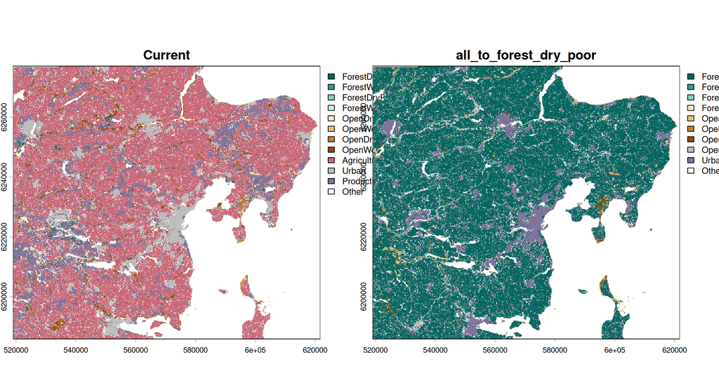

```r
pal <- c(
  ForestDryPoor = "#01665e", ForestWetPoor = "#35978f",
  ForestDryRich = "#80cdc1", ForestWetRich = "#c7eae5",
  OpenDryPoor = "#f6e8c3", OpenWetPoor = "#dfc27d",
  OpenDryRich = "#bf812d", OpenWetRich = "#8c510a",
  Agriculture = "#CC6677", Urban = "grey",
  ProductionForest = "#80739B", Other = "white"
)
plot(
  c(terra::rast(current_local_output_path),
    terra::rast(scenario_audit$landuse_path[[1]])),
  type = "classes", col = unname(pal[class_table$class]),
  main = c("Current", scenario_audit$scenario[[1]])
)
```

# 13 Next: plant biodiversity

Use targets_plant_biodiversity.R in the same project root. It has its own _targets_plant_biodiversity cache and Results/gudenaa_plant_biodiversity outputs; it does not use or modify _targets_climate or _targets_diversity_pilot.

The modelling script calibrates thresholds and range weights from national baseline predictions, then applies the same fitted model, threshold and weight to all nine local conditions. National baseline binary rasters are saved for range-size estimation; **the biodiversity comparison maps are local**.

Start with the input/selection checks and the 30-species pilot described at the top of that script. Do not launch the full national species list merely to check that the paths are correct.